# Healthcare Digest

**Week of September 7, 2026**Market data through: September 4, 2026Narrative created: September 7, 2026

Weekly review of healthcare services, technology, distribution, and diagnostic company performance, changes, earnings activity, and strategy narrative.

## In the News

### Executive Summary

- **Medicaid eligibility operations acquired a new source of friction.** CMS’s September 4 citizenship-verification guidance introduces additional documentary and parental-attestation pathways, creating near-term systems, call-center and appeals work for states and potentially more enrollment volatility for Medicaid plans.
- **Payment integrity’s weak point is often reference data, not detection algorithms.** HHS-OIG found $587.7 million of ineligible Part D payments caused by obsolete prescription-status data and the absence of a rejection deadline after drugs moved over the counter.
- **Traditional employer-group insurance is becoming more segmented.** Health Net’s California and Oregon exit, coupled with new CBO evidence of migration toward level-funded and other non-community-rated arrangements, strengthens the thesis that carriers are concentrating capital where risk and administration are more controllable.
- **Oracle Health’s largest deployment remains an execution liability rather than an unqualified reference account.** Congressional subpoenas and unresolved GAO recommendations increase scrutiny as the VA accelerates implementation.
- **Overall environment: modestly deteriorated for Medicaid administration and large-platform execution, mixed for commercial payers, and improved for eligibility, payment-integrity and implementation-services demand.**

### 1. CMS adds a new verification layer to Medicaid and CHIP eligibility

**What happened**

On September 4, CMS issued prospective guidance implementing Executive Order 14418 when an applicant or beneficiary asserts U.S. citizenship as the basis for Medicaid or CHIP eligibility. The document reiterates electronic or documentary verification requirements but introduces a framework under which certain applicants using separate citizenship and identity documents must also supply a qualifying parent document or parental attestation. Where neither parent has documentary evidence of citizenship, a parent may attest that none of the exclusions specified by the executive order applies.

CMS said the guidance became effective upon publication, subject to applicable law. It is distinct from—but operationally adjacent to—the October 1, 2026 restrictions on federal Medicaid and CHIP matching funds for specified noncitizen categories. [CMS, “CMS Guidance on Continuing to Protect the Meaning and Value of American Citizenship … for Medicaid and CHIP Verification Requirements,” September 4, 2026](https://www.hhs.gov/sites/default/files/citizenship-eo-14418-guidance-cms.pdf). ([hhs.gov](https://www.hhs.gov/sites/default/files/citizenship-eo-14418-guidance-cms.pdf))

**Implication**

The first-order effect is administrative rather than actuarial. States may need to modify eligibility rules, document-management systems, notices, staff scripts and appeal workflows while clarifying how the new pathway interacts with automated Social Security Administration verification. Eligibility-platform, systems-integration and document-processing demand should rise immediately.

For Medicaid MCOs, the risk is increased procedural churn: delayed determinations or documentation failures could interrupt capitation and care-management continuity even when underlying eligibility has not economically changed. Providers would absorb the corresponding risk through coverage uncertainty and uncompensated care. Magnitude is not yet measurable, and implementation or litigation could materially change the outcome.

**Watch next**

State implementation instructions; CMS technical guidance on automated verification and pending applications; legal challenges; and whether states report higher denial, pending-case or appeal volumes.

### 2. OIG exposes a $587.7 million Part D reference-data failure

**What happened**

HHS-OIG reported on August 31 that Part D sponsors made $587.7 million of ineligible payments from 2021 through 2023 for five drugs that remained labeled prescription-only after their brand-name equivalents became available over the counter. OIG attributed the failure to obsolete FDA information in CMS’s Part D Formulary Reference File and CMS’s lack of a deadline for sponsors to reject claims after an Rx-to-OTC switch.

CMS concurred with OIG’s recommendation to establish a rejection timeframe. OIG did **not** recommend recovering the full $587.7 million, so the estimate should not be treated as a disclosed sponsor repayment liability. HHS-OIG, “CMS Oversight Did Not Prevent Medicare Part D Sponsors From Making $587.7 Million in Ineligible Payments,” August 31, 2026. (oig.hhs.gov)

**Implication**

This qualifies last week’s evidence that CMS is moving payment integrity toward prepayment intervention. Sophisticated anomaly models cannot compensate for incorrect product-status data embedded in the adjudication stack.

Part D plans and PBMs need tighter synchronization across FDA labeling, CMS formulary files, National Drug Codes and point-of-sale edits. The commercial opportunity favors vendors that combine regulatory reference-data management with configurable claims rules, exception handling and audit trails—not analytics alone. Sponsors face remediation costs and prospective leakage reduction, but a reliable public estimate of direct plan-level exposure is unavailable.

**Watch next**

CMS’s rejection deadline; whether sponsors must review historical prescription-drug-event records; and whether OIG expands the methodology to terminated NDCs, excluded products or other formulary-status mismatches.

### 3. Health Net’s exit reinforces the structural thinning of traditional group insurance

**What happened**

Health Net began notifying employers and brokers on September 1 that it will exit traditional small- and large-group HMO, PPO and POS products in California and Oregon. Coverage will generally end February 28, 2027. Centene said the decision does not affect Marketplace, Medicaid or Medicare products and reflects a decision to focus on government-sponsored coverage. [Becker’s Payer Issues, “Centene’s Health Net to Exit Commercial Group Market in California, Oregon,” September 2, 2026](https://www.beckerspayer.com/payer/centenes-health-net-to-exit-commercial-group-market-in-california-oregon/). ([beckerspayer.com](https://www.beckerspayer.com/payer/centenes-health-net-to-exit-commercial-group-market-in-california-oregon/))

Separately, CBO’s new small-business market analysis found that only 53% of small-business employees worked for firms offering coverage in 2024. Enrollment in small-business plans grew 10% from 2014 to 2024 while small-business employment grew 21%. Community-rated products fell to 50% of enrollment, while self-insured and other non-community-rated arrangements reached 46%, driven largely by level-funded plans. CBO said migration by healthier groups may have worsened risk in the community-rated pool, although multiple factors affect premiums. [Congressional Budget Office, “Health Insurance Options for Small Businesses,” September 2026](https://www.cbo.gov/publication/62745). ([cbo.gov](https://www.cbo.gov/publication/62745))

**Implication**

The combined evidence points to segmentation rather than a simple contraction of employer coverage. Carriers can prioritize Medicaid, Medicare and ACA markets while healthier or more predictable employer groups migrate toward level funding, stop-loss and other experience-sensitive arrangements.

That creates demand for underwriting data, stop-loss administration, benefit-navigation and ICHRA infrastructure, but potentially weakens community-rated risk pools. Providers should expect payer-mix migration and contract-transition work rather than assume affected members will become uninsured. State-specific membership and competitive-share effects remain publicly unavailable.

**Watch next**

Health Net’s regulatory filings; replacement-carrier decisions during employer renewals; and whether other regional carriers reduce traditional group exposure for 2027.

### 4. VA oversight weakens Oracle Health’s enterprise-execution thesis

**What happened**

GAO reported that the VA had not fully implemented 14 of 18 recommendations covering cost estimates, schedules, program management, user adoption and operational testing. The department has provided Congress with a notional deployment schedule but not the detailed documentation or updated cost estimate GAO requested. VA nevertheless plans nine additional deployments during 2026 and approximately 170 sites by 2031. [GAO, “VA Electronic Health Record Modernization: Actions Needed to Sustain Accelerated System Deployments,” September 2, 2026](https://www.gao.gov/products/gao-26-109393). ([gao.gov](https://www.gao.gov/products/gao-26-109393))

On September 2, the House Veterans’ Affairs Committee voted 19-0 to authorize subpoenas compelling Oracle Executive Chairman Larry Ellison and CEO Mike Sicilia to testify. A hearing date has not been announced. [U.S. House Committee on Veterans’ Affairs, “Beyond Go-Live: VA Electronic Health Record Modernization Status Update,” updated September 3, 2026](https://docs.house.gov/Committee/Calendar/ByEvent.aspx?EventID=119517). ([docs.house.gov](https://docs.house.gov/Committee/Calendar/ByEvent.aspx?EventID=119517))

**Implication**

The new information does not establish commercial customer losses, but it raises the burden of proof for Oracle Health as an enterprise modernization platform. Accelerating deployment before core governance recommendations are closed increases demand for migration, testing, training, data-quality and independent-assurance services while raising the probability of costly remediation.

Health systems evaluating large platform conversions are likely to demand clearer milestone accountability, user-adoption measures and operational testing rather than relying on technical go-live status.

**Watch next**

The subpoena hearing; VA’s updated lifecycle cost estimate and detailed schedule; and performance at the next deployment cohort.

### What I'm Watching Next

- **September 21, 2026:** Comments are due on CMS’s proposed implementation of new Medicaid provider-tax hold-harmless thresholds. [CMS, “Amending the Indirect Hold Harmless Threshold of Health Care-Related Taxes Proposed Rule,” July 21, 2026](https://www.cms.gov/newsroom/fact-sheets/amending-indirect-hold-harmless-threshold-health-care-related-taxes-proposed-rule-cms-2452-p). ([cms.gov](https://www.cms.gov/newsroom/fact-sheets/amending-indirect-hold-harmless-threshold-health-care-related-taxes-proposed-rule-cms-2452-p?utm_source=openai))
- **October 1, 2026:** New federal Medicaid and CHIP matching-fund restrictions for specified noncitizen categories take effect, increasing the stakes of state eligibility-system readiness. ([hhs.gov](https://www.hhs.gov/sites/default/files/citizenship-eo-14418-guidance-cms.pdf))

### Bottom Line

The most important weekly change is CMS’s new Medicaid and CHIP citizenship-verification framework because it can transmit quickly from policy into enrollment operations, MCO capitation and provider collections. Eligibility-system execution requires the closest attention. The next major catalyst is the October 1 federal matching-fund change, which will show whether states can implement overlapping eligibility restrictions without materially increasing procedural coverage loss.

## Notable Changes

Comparison with the final report dated August 31, 2026 (market data through August 28, 2026).

### Sectors

#### Top-three comparison

| Entity | Previous | Current | Change | Current return |
| --- | --- | --- | --- | --- |
| Precision Diagnostics | #1 | #1 | — 0 | +88.7% |
| Inpatient Non-Acute Providers | #2 | #2 | — 0 | +64.9% |
| Value-Based Care | #3 | #3 | — 0 | +56.1% |

### Stocks

#### Top-three comparison

| Entity | Previous | Current | Change | Current return |
| --- | --- | --- | --- | --- |
| 10x Genomics (TXG) | #1 | #1 | — 0 | +348.8% |
| PACS Group (PACS) | #2 | #2 | — 0 | +280.5% |
| Agilon Health (AGL) | #3 | #3 | — 0 | +195.0% |

#### Largest rank changes

| Entity | Previous | Current | Change | Current return |
| --- | --- | --- | --- | --- |
| Astrana Health (ASTH) | #35 | #29 | ↑ 6 | +29.5% |
| Quest Diagnostics (DGX) | #24 | #31 | ↓ 7 | +29.2% |
| Progyny (PGNY) | #42 | #36 | ↑ 6 | +15.0% |

### Subcategory movement since the previous report

| Subcategory | Move | Last Report, 12m Ret | Current Report, 12m Ret |
| --- | --- | --- | --- |
| Health IT and Data | +4.3% | -23.3% | -21.8% |
| Pharma Distribution | +2.8% | +31.3% | +34.8% |
| Payers | +2.1% | +27.5% | +28.8% |
| Outpatient and Home Providers | +1.1% | +44.2% | +46.2% |
| Precision Diagnostics | -0.1% | +84.5% | +88.7% |
| Inpatient Non-Acute Providers | -0.4% | +64.0% | +64.9% |
| Health Care Real Estate | -0.9% | +34.5% | +33.5% |
| Digital Health, Specialty, Benefits | -1.3% | +4.3% | +2.0% |
| Value-Based Care | -1.5% | +52.6% | +56.1% |
| Health System Providers | -2.5% | +9.5% | +2.1% |

### Largest company moves

| Direction | Company | Ticker | Move |
| --- | --- | --- | --- |
| Gain | Definitive Healthcare | DH | +30.9% |
| Gain | Accendra Health | AHCO | +12.1% |
| Gain | Amwell | AMWL | +8.9% |
| Decline | Phreesia | PHR | -10.0% |
| Decline | Consensus Cloud Solutions | CCSI | -6.9% |
| Decline | Evolent Health | EVH | -6.1% |

## Subcategory Performance

| Subcategory | Companies | Market cap | 3m Return | 12m Return | 24m Return |
| --- | --- | --- | --- | --- | --- |
| Payers | 10 | $769.8B | +1.0% | +28.8% | -7.8% |
| Health System Providers | 5 | $119.8B | +19.1% | +2.1% | +12.7% |
| Inpatient Non-Acute Providers | 4 | $31.4B | +10.8% | +64.9% | +14.2% |
| Health Care Real Estate | 8 | $266.4B | +11.3% | +33.5% | +66.6% |
| Value-Based Care | 5 | $7.2B | -4.0% | +56.1% | -5.2% |
| Outpatient and Home Providers | 11 | $64.8B | +13.2% | +46.2% | +85.5% |
| Digital Health, Specialty, Benefits | 10 | $26.3B | +11.8% | +2.0% | +47.1% |
| Health IT and Data | 12 | $470.6B | -11.7% | -21.8% | +13.0% |
| Pharma Distribution | 5 | $222.6B | +18.4% | +34.8% | +76.9% |
| Precision Diagnostics | 12 | $168.6B | +35.2% | +88.7% | +161.3% |

Subcategory returns use the most recently saved market capitalizations as weights.

## Stock Performance vs. SPY

The same selected stocks appear in every chart. Each line is labeled at the right with its ticker and return for the displayed window.

### Last 6 months

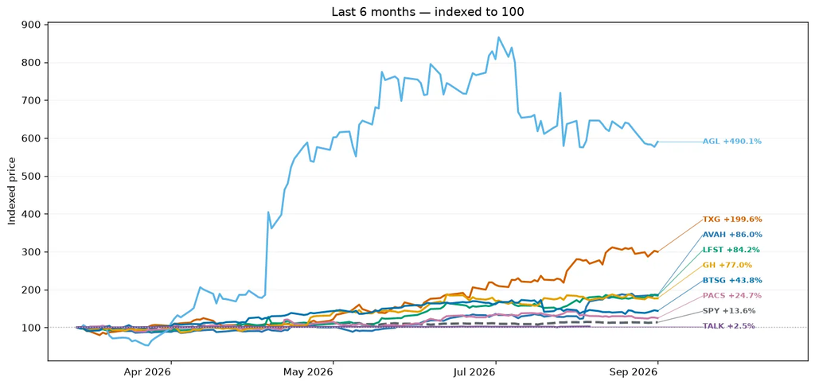

### Last 12 months

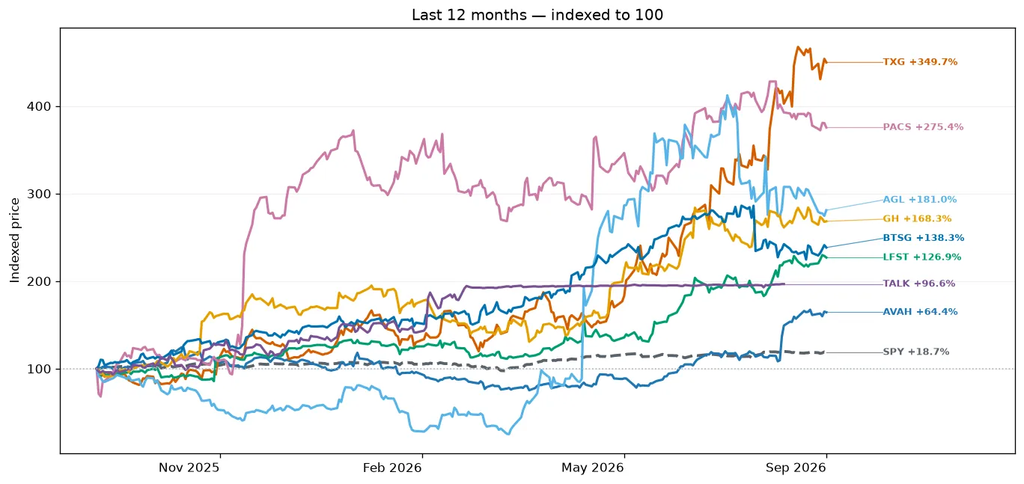

### Last 24 months

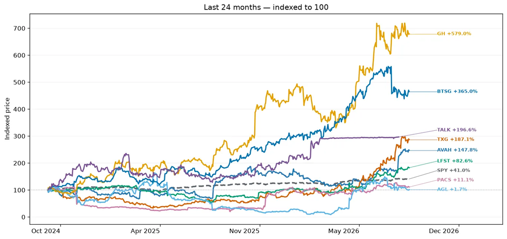

## Current Top Stocks

### Last 3 months

| Rank | Company | Ticker | Market cap | Return |
| --- | --- | --- | --- | --- |
| 1 | Aveanna Healthcare | AVAH | $2.0B | +103.3% |
| 2 | 10x Genomics | TXG | $6.1B | +101.8% |
| 3 | Lifestance Health | LFST | $4.0B | +71.8% |
| 4 | Tenet Health | THC | $20.5B | +63.6% |
| 5 | NeoGenomics | NEO | $2.1B | +59.4% |

### Last 12 months

| Rank | Company | Ticker | Market cap | Return |
| --- | --- | --- | --- | --- |
| 1 | 10x Genomics | TXG | $6.1B | +348.8% |
| 2 | PACS Group | PACS | $7.3B | +280.5% |
| 3 | Agilon Health | AGL | $2.1B | +195.0% |
| 4 | Guardant Health | GH | $21.4B | +168.4% |
| 5 | BrightSpring Health Services | BTSG | $12.4B | +151.7% |

### Last 24 months

| Rank | Company | Ticker | Market cap | Return |
| --- | --- | --- | --- | --- |
| 1 | Guardant Health | GH | $21.4B | +580.2% |
| 2 | BrightSpring Health Services | BTSG | $12.4B | +369.7% |
| 3 | Talkspace | TALK | $874.4M | +193.3% |
| 4 | 10x Genomics | TXG | $6.1B | +190.9% |
| 5 | Natera | NTRA | $39.4B | +190.7% |

## Companies by Subcategory

### PayersLast 3m: +1.0%

| Company | Ticker | Market cap | 3m Return | 12m Return | 24m Return |
| --- | --- | --- | --- | --- | --- |
| UnitedHealth | UNH | $380.1B | -0.6% | +25.9% | -33.5% |
| CVS Health | CVS | $135.1B | +0.8% | +31.1% | +67.5% |
| Humana | HUM | $43.7B | +14.7% | +30.4% | +12.2% |
| Oscar Health | OSCR | $9.4B | +31.6% | +66.0% | +89.8% |
| Molina Healthcare | MOH | $10.2B | +5.2% | +15.0% | -38.7% |
| Cigna | CI | $73.7B | -2.4% | -7.5% | -20.1% |
| Elevance | ELV | $81.5B | -1.9% | +29.9% | -24.8% |
| Clover Health | CLOV | $2.2B | +11.1% | +54.7% | +69.5% |
| Centene | CNC | $30.7B | +7.6% | +131.3% | -5.4% |
| Alignment Health | ALHC | $3.1B | -11.9% | -14.6% | +42.5% |

### Health System ProvidersLast 3m: +19.1%

| Company | Ticker | Market cap | 3m Return | 12m Return | 24m Return |
| --- | --- | --- | --- | --- | --- |
| HCA Healthcare | HCA | $87.2B | +8.8% | -3.7% | +4.4% |
| Tenet Health | THC | $20.5B | +63.6% | +35.1% | +72.8% |
| Universal Health Services | UHS | $10.2B | +16.9% | -10.8% | -26.0% |
| Community Health Systems | CYH | $417.4M | +5.5% | -1.0% | -49.3% |
| Ardent Health Partners | ARDT | $1.5B | +25.7% | -17.1% | -43.1% |

### Inpatient Non-Acute ProvidersLast 3m: +10.8%

| Company | Ticker | Market cap | 3m Return | 12m Return | 24m Return |
| --- | --- | --- | --- | --- | --- |
| The Ensign Group | ENSG | $10.4B | +0.3% | -1.8% | +14.6% |
| Acadia Healthcare | ACHC | $2.8B | +14.9% | +18.6% | -63.2% |
| Encompass Health | EHC | $11.0B | +17.1% | -3.0% | +32.9% |
| PACS Group | PACS | $7.3B | +14.8% | +280.5% | +14.6% |

### Health Care Real EstateLast 3m: +11.3%

| Company | Ticker | Market cap | 3m Return | 12m Return | 24m Return |
| --- | --- | --- | --- | --- | --- |
| Healthpeak properties | DOC | $15.1B | +4.3% | +12.3% | -6.1% |
| Ventas, Inc | VTR | $48.0B | +10.1% | +32.9% | +43.6% |
| Medical Properties Trust | MPT | $2.8B | -19.5% | — | — |
| National Health Investors | NHI | $3.7B | +0.6% | -9.6% | -13.9% |
| Omega Healthcare Investors | OHI | $15.1B | +4.3% | +7.5% | +17.0% |
| Welltower | WELL | $166.9B | +14.1% | +40.7% | +89.5% |
| CareTrust REIT | CTRE | $9.6B | +2.7% | +14.9% | +31.0% |
| Sabra Health Care REIT | SBRA | $5.3B | +12.6% | +9.2% | +20.5% |

### Value-Based CareLast 3m: -4.0%

| Company | Ticker | Market cap | 3m Return | 12m Return | 24m Return |
| --- | --- | --- | --- | --- | --- |
| Privia Health Group | PRVA | $3.0B | -4.5% | -11.3% | +10.7% |
| Astrana Health | ASTH | $1.8B | +1.3% | +29.5% | -19.2% |
| Agilon Health | AGL | $2.1B | -8.6% | +195.0% | -1.9% |
| Evolent Health | EVH | $347.6M | +2.4% | -55.0% | -85.8% |
| P3 Health | PIII | $32.7M | -19.3% | +6.6% | -59.3% |

### Outpatient and Home ProvidersLast 3m: +13.2%

| Company | Ticker | Market cap | 3m Return | 12m Return | 24m Return |
| --- | --- | --- | --- | --- | --- |
| Davita | DVA | $15.4B | -4.3% | +33.5% | +22.7% |
| Fresenius | FMS | $13.8B | +2.9% | -8.5% | +15.1% |
| Surgery Partners | SGRY | $2.0B | +4.0% | -36.7% | -52.8% |
| Option Care Health | OPCH | $3.4B | +18.0% | -16.8% | -24.6% |
| Lifestance Health | LFST | $4.0B | +71.8% | +137.1% | +83.2% |
| Chemed (Vitas) | CHE | $7.1B | +17.7% | +11.6% | -9.0% |
| Addus HomeCare | ADUS | $2.1B | +28.9% | +4.9% | -6.0% |
| Pennant Group | PNTG | $1.3B | +19.8% | +56.4% | +19.3% |
| US Physical Therapy | USPH | $1.2B | +25.1% | -7.3% | -6.2% |
| BrightSpring Health Services | BTSG | $12.4B | +5.8% | +151.7% | +369.7% |
| Aveanna Healthcare | AVAH | $2.0B | +103.3% | +65.2% | +150.6% |

### Digital Health, Specialty, BenefitsLast 3m: +11.8%

| Company | Ticker | Market cap | 3m Return | 12m Return | 24m Return |
| --- | --- | --- | --- | --- | --- |
| Teladoc | TDOC | $1.2B | -10.9% | -19.7% | -16.4% |
| Amwell | AMWL | $179.6M | +50.7% | +86.1% | +63.8% |
| Talkspace | TALK | $874.4M | +0.6% | +101.1% | +193.3% |
| Hims & Hers | HIMS | $6.4B | +5.8% | -42.8% | +103.0% |
| LifeMD | LFMD | $169.3M | -37.0% | -49.2% | -35.7% |
| Omada Health | OMDA | $1.2B | +27.0% | -6.2% | — |
| GoodRx | GDRX | $1.0B | +31.3% | -13.0% | -54.9% |
| Progyny | PGNY | $2.5B | +0.3% | +15.0% | +11.9% |
| Concentra Group | CON | $4.0B | +36.1% | +49.3% | +42.0% |
| HealthEquity | HQY | $8.8B | +8.3% | +5.0% | +26.0% |

### Health IT and DataLast 3m: -11.7%

| Company | Ticker | Market cap | 3m Return | 12m Return | 24m Return |
| --- | --- | --- | --- | --- | --- |
| Oracle-Cerner | ORCL | $374.1B | -25.7% | -31.8% | +12.0% |
| Veradigm | MDRX | n/a | -4.0% | -1.2% | -50.5% |
| Waystar | WAY | $4.0B | +25.4% | -32.7% | -8.3% |
| Solventum | SOLV | $13.6B | +13.2% | +26.1% | +38.5% |
| Phreesia | PHR | $663.2M | +14.7% | -61.1% | -53.5% |
| Consensus Cloud Solutions | CCSI | $669.7M | +5.6% | +31.9% | +55.8% |
| Definitive Healthcare | DH | $85.5M | +17.1% | -73.8% | -75.6% |
| Iqvia | IQV | $38.7B | +46.0% | +42.7% | +10.2% |
| Health Catalyst | HCAT | $154.4M | -12.4% | -50.0% | -76.8% |
| Doximity | DOCS | $3.8B | +28.0% | -62.0% | -27.5% |
| Veeva Systems | VEEV | $33.1B | +59.4% | +0.8% | +27.4% |
| Omnicell | OMCL | $1.7B | -20.1% | +7.0% | -24.1% |

### Pharma DistributionLast 3m: +18.4%

| Company | Ticker | Market cap | 3m Return | 12m Return | 24m Return |
| --- | --- | --- | --- | --- | --- |
| McKesson | MCK | $97.2B | +17.1% | +32.1% | +80.1% |
| Cardinal Health | CAH | $54.7B | +20.2% | +65.3% | +121.2% |
| Cencora | COR | $59.6B | +20.3% | +13.1% | +40.8% |
| Accendra Health | AHCO | $912.9M | -34.4% | -31.8% | -41.5% |
| Henry Schein | HSIC | $10.2B | +16.0% | +29.4% | +30.5% |

### Precision DiagnosticsLast 3m: +35.2%

| Company | Ticker | Market cap | 3m Return | 12m Return | 24m Return |
| --- | --- | --- | --- | --- | --- |
| Natera | NTRA | $39.4B | +52.4% | +95.3% | +190.7% |
| NeoGenomics | NEO | $2.1B | +59.4% | +117.8% | +8.4% |
| BillionToOne | BLLN | $6.5B | +2.3% | — | — |
| Guardant Health | GH | $21.4B | +28.5% | +168.4% | +580.2% |
| Tempus AI | TEM | $8.5B | +39.2% | -18.8% | +28.8% |
| Illumina | ILMN | $30.7B | +34.4% | +120.6% | +75.4% |
| 10x Genomics | TXG | $6.1B | +101.8% | +348.8% | +190.9% |
| PacBio | PACB | $447.3M | -6.9% | +6.3% | -14.6% |
| QuidelOrtho | QDEL | $1.2B | -2.5% | -51.3% | -67.8% |
| Quest Diagnostics | DGX | $25.8B | +18.4% | +29.2% | +55.1% |
| Labcorp Holdings | LH | $25.3B | +23.3% | +17.3% | +46.0% |
| Certara | CERT | $1.2B | +47.9% | -24.5% | -30.3% |

## Upcoming Earnings

### Health IT and Data

| Company | Ticker | Date | Market cap | 3m Return | 12m Return |
| --- | --- | --- | --- | --- | --- |
| Oracle-Cerner | ORCL | September 10, 2026 | $374.1B | -25.7% | -31.8% |

## Recent Earnings Highlights — 3m Ret

Companies covered in this section:

- Phreesia (PHR)

### Phreesia (PHR) +14.7%

**Reported:** September 2, 2026 · [Google Finance earnings page](https://www.google.com/finance/quote/PHR:NYSE?tab=earnings&hl=en)

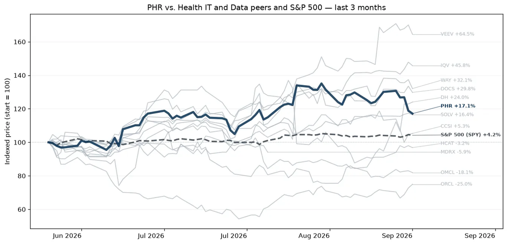

#### Earnings Call Summary

Phreesia delivered a solid Q2 fiscal 2027, with revenue growing 10% year-over-year to $129.5 million. The company generated positive operating and free cash flow, allowing it to reduce debt principal by over $23 million while maintaining a healthy cash balance.

#### At a Glance

- **Phreesia Beats Revenue, Misses EPS Estimates:** Phreesia reported Q2 fiscal 2027 revenue of $129.46 million, slightly beating estimates of $128.99 million, but posted a reported adjusted EPS of $0.00 compared to expectations of $0.32.
- **Core Client Metrics Show Moderate Growth:** Average Health Care Services Clients rose 6% year-over-year to 4,744, while total revenue per client increased 4% to $27,289, demonstrating stable monetization despite slowing customer acquisition rates.
- **Full-Year Fiscal 2027 Guidance Reaffirmed:** The company maintained its full-year guidance, projecting total revenue between $510 million and $520 million and adjusted EBITDA between $125 million and $135 million.
- **Strategic Acquisitions Drive Incremental Growth:** Early commercial traction from the AccessOne patient financing platform and strong momentum in ProviderConnect digital marketing campaigns emerged as key strategic growth drivers.
- **Restructuring Plan Enhances Profitability Margins:** Adjusted EBITDA increased to $32.9 million with a 25% margin, driven by efficiency gains from a corporate restructuring plan initiated in May.
- **Stock Declines Due to Margin Reinvestment:** Shares fell after-hours as investors expressed concern over the earnings miss and management's choice to reinvest cost savings back into the business rather than raising the full-year outlook.

#### Key Moments from the Call

- **7m 20s — Maintained Fiscal 2027 Guidance:** Phreesia reiterated its fiscal 2027 revenue guidance of $510 million-$520 million and Adjusted EBITDA of $125 million-$135 million. Investors will appreciate the stability, supported by disciplined cost control, despite sequential legacy payment revenue declines and pricing adjustments to ease financial strain on provider clients.
- **9m 29s — AccessOne Strategic Progress:** Management expressed growing confidence in the AccessOne acquisition, citing positive client feedback and early market wins for consumer financing solutions. The expanded securitization facility allows upfront funding to non-investment grade clients, turning the integration into a key multi-year growth lever.
- **10m 50s — Network Solutions Momentum and GLP-1 Lift:** The Network Solutions business showed significant second-half activity, boosted by new offerings like ProviderConnect. A noted GLP-1 campaign study demonstrated a 4% incremental lift in new-to-brand prescriptions, helping Phreesia secure new business and build commercial confidence.
- **21m 2s — AI-Driven Growth Acceleration:** CEO Chaim Indig emphasized that AI is transforming Phreesia's product landscape via automation tools like PlanMatch and VoiceAI. He stated that AI has expanded long-term opportunities, leaving him more optimistic about potential future growth acceleration than ever before.

## Company Overviews

### UnitedHealth (UNH)

*Payers · $380.1B · 3m -0.6% · 12m +25.9% · 24m -33.5%*

[Google Finance](https://www.google.com/finance/quote/UNH:NYSE?tab=earnings&hl=en)

Diversified healthcare company operating UHC insurance businesses and the Optum health services platform.

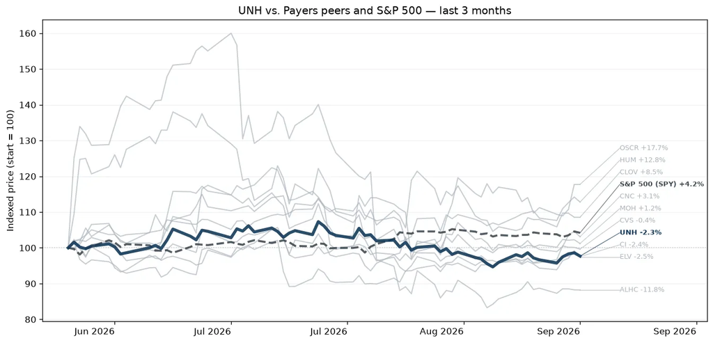

UnitedHealth Group is one of the largest private health insurers and provides medical benefits to about 51 million members globally, including 1 million outside the US as of December 2025. As a leader in employer-sponsored, self-directed, and government-backed insurance plans, UnitedHealth has obtained massive scale in medical insurance. Along with its insurance assets, UnitedHealth's Optum franchises help create a healthcare services colossus that spans everything from pharmaceutical benefits to providing outpatient care and analytics to affiliates and third parties.

### CVS Health (CVS)

*Payers · $135.1B · 3m +0.8% · 12m +31.1% · 24m +67.5%*

[Google Finance](https://www.google.com/finance/quote/CVS:NYSE?tab=earnings&hl=en)

Healthcare retail ecosystem.

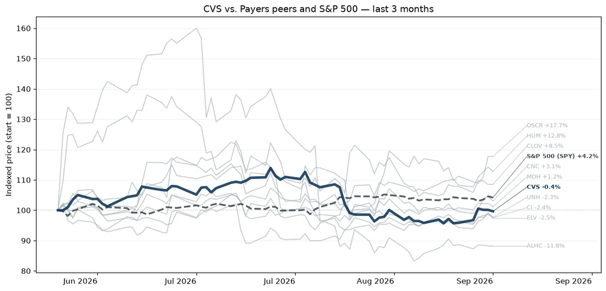

CVS Health offers a diverse set of healthcare services. Its roots are in its retail pharmacy operations, where it operates around 9,000 stores primarily in the US. CVS is also a large pharmacy benefit manager (acquired through Caremark), processing about 2 billion adjusted claims annually. It operates a top-tier health insurer (acquired through Aetna) through which it serves about 27 million medical members. The acquisition of Oak Street Health added primary care services to the mix, which could have significant synergies with all existing business lines.

### Humana (HUM)

*Payers · $43.7B · 3m +14.7% · 12m +30.4% · 24m +12.2%*

[Google Finance](https://www.google.com/finance/quote/HUM:NYSE?tab=earnings&hl=en)

Large payer, Medicare and Medicare Advantage focused.

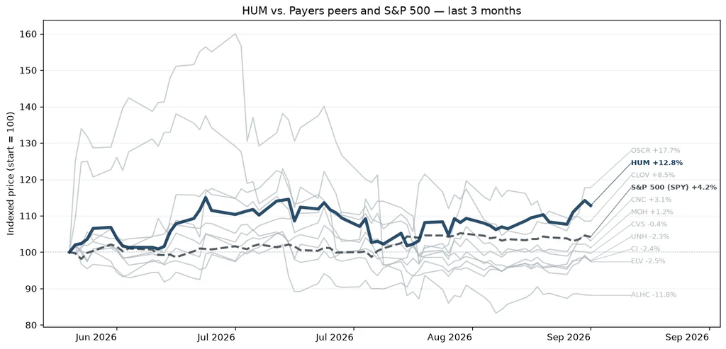

Humana is one of the largest private health insurers in the US, and the firm has built a niche specializing in government-sponsored programs, with nearly all its medical membership stemming from Medicare, Medicaid, and the military's Tricare program. Beyond medical insurance, the company provides other healthcare services, including primary-care services, at-home services, and pharmacy benefit management.

### Oscar Health (OSCR)

*Payers · $9.4B · 3m +31.6% · 12m +66.0% · 24m +89.8%*

[Google Finance](https://www.google.com/finance/quote/OSCR:NYSE?tab=earnings&hl=en)

Tech-focused payer with large exposure to exchange products and ICHRAs.

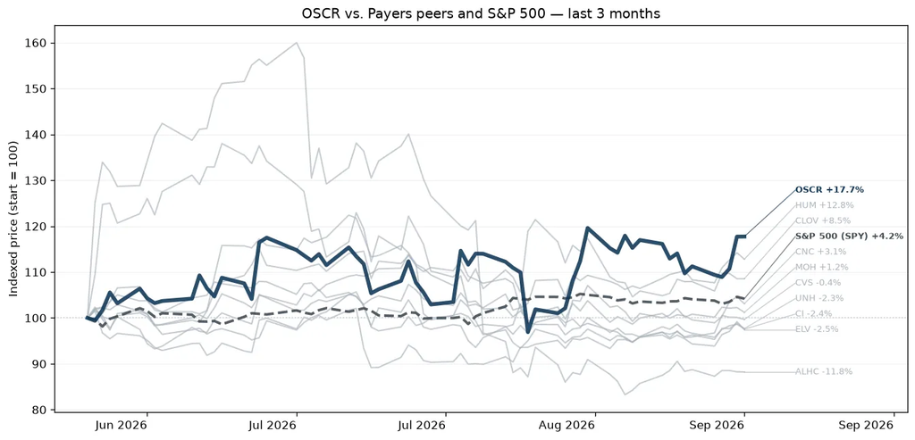

Oscar Health Inc is a healthcare technology company built around a full stack technology platform and a relentless focus on serving its members. It offers Individual & Family plans and health technology solutions that power the healthcare industry. Oscar operates as one segment to sell insurance to individuals, families and employees through the federal and state-run healthcare exchanges formed in conjunction with the Patient Protection and Affordable Care Act (ACA) and leverages its technology platform to provide services via its Oscar offering.

### Molina Healthcare (MOH)

*Payers · $10.2B · 3m +5.2% · 12m +15.0% · 24m -38.7%*

[Google Finance](https://www.google.com/finance/quote/MOH:NYSE?tab=earnings&hl=en)

Managed-care company providing health insurance through government programs.

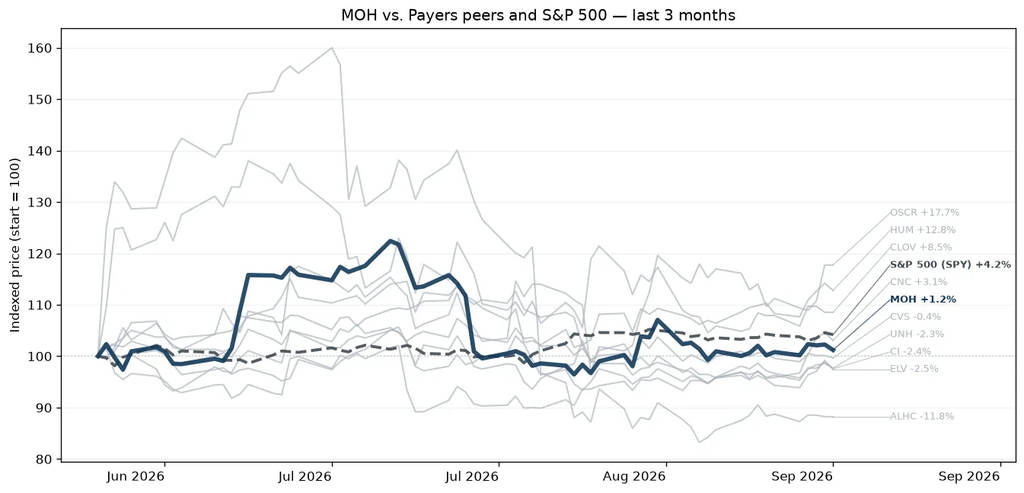

Molina Healthcare Inc provides medical insurance plans through Medicaid, the individual exchanges, and Medicare. The company operates in four reportable segments consisting of: 1) Medicaid; 2) Medicare; 3) Marketplace; and 4) Other. It manages health benefit risks for more than 5 million people, with more than 85% of those members coming through contracts with state governments for their Medicaid programs. Medicaid contracts in four states-California, New York, Texas, and Washington-account for over half of its enrollees.

### Cigna (CI)

*Payers · $73.7B · 3m -2.4% · 12m -7.5% · 24m -20.1%*

[Google Finance](https://www.google.com/finance/quote/CI:NYSE?tab=earnings&hl=en)

Employer-focused health insurance company.

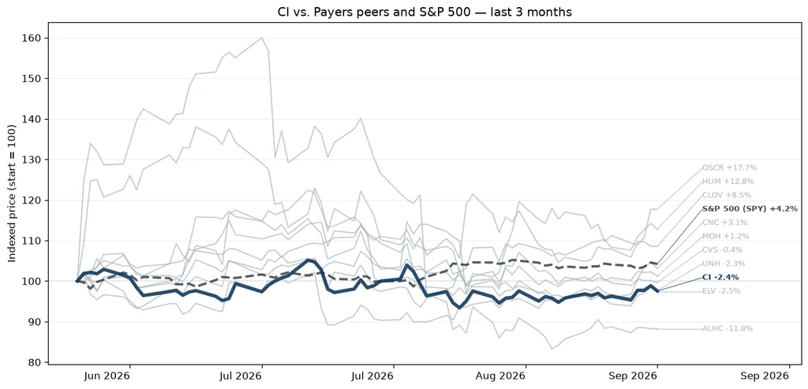

Cigna primarily provides pharmacy benefit management and health insurance services. Its PBM and specialty pharmacy services, which were greatly expanded by its 2018 merger with Express Scripts, are mostly sold to health insurance plans and employers. Its largest PBM contract is with the Department of Defense, and it recently won a multiyear deal with top-tier insurer Centene. In health insurance and other benefits, Cigna primarily serves employers through self-funding arrangements, and the company operates mostly in the US with 16 million US and 2 million international medical members covered as of December 2025.

### Elevance (ELV)

*Payers · $81.5B · 3m -1.9% · 12m +29.9% · 24m -24.8%*

[Google Finance](https://www.google.com/finance/quote/ELV:NYSE?tab=earnings&hl=en)

Health insurance company, previously named Anthem.

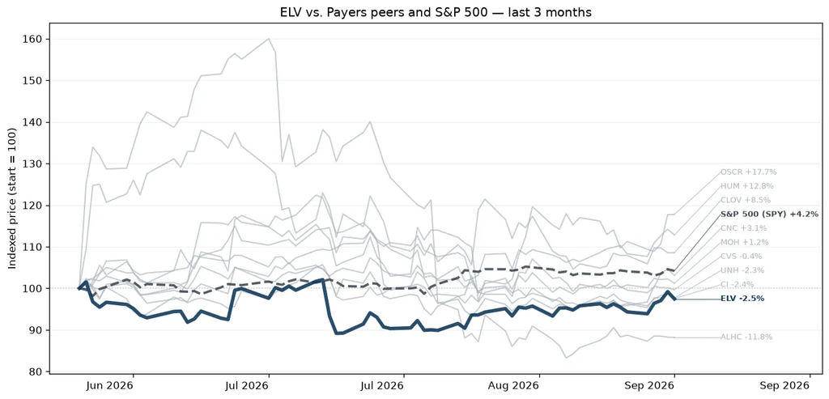

Elevance Health remains one of the leading health insurers in the US, providing medical benefits to 45 million medical members at the end of 2025. The company offers employer, individual, and government-sponsored coverage plans. Elevance differs from its peers in its unique position as the largest single provider of Blue Cross Blue Shield branded coverage, operating as the licensee for the Blue Cross Blue Shield Association in 14 states. Through acquisitions, such as the Amerigroup deal in 2012 and MMM in 2021, Elevance's reach expands beyond those states in government-sponsored programs, such as Medicaid and Medicare Advantage plans, too. It is also an emerging player in pharmacy benefit management and other healthcare services.

### Clover Health (CLOV)

*Payers · $2.2B · 3m +11.1% · 12m +54.7% · 24m +69.5%*

[Google Finance](https://www.google.com/finance/quote/CLOV:NASDAQ?tab=earnings&hl=en)

American healthcare company company providing Medicare Advantage insurance plans.

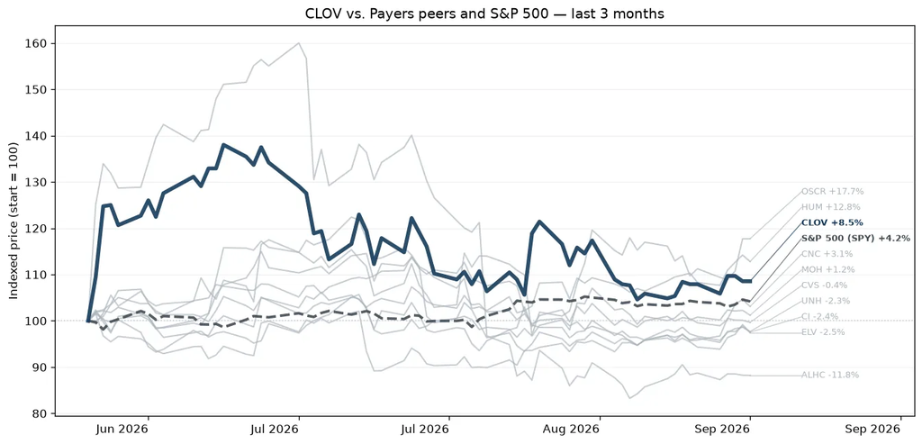

Clover Health Investments Corp is a healthcare technology company. It focuses on empowering Medicare physicians to proactively manage chronic diseases through its proprietary software platform, Clover Assistant. This cloud-based solution provides personalized insights to physicians, enabling early detection and management of chronic conditions. It operates in one segment: Insurance, through which it offers PPO and HMO plans to Medicare Advantage members in several states.

### Centene (CNC)

[Google Finance](https://www.google.com/finance/quote/CNC:NYSE?tab=earnings&hl=en)

Health insurance for government and privately insured healthcare programs.

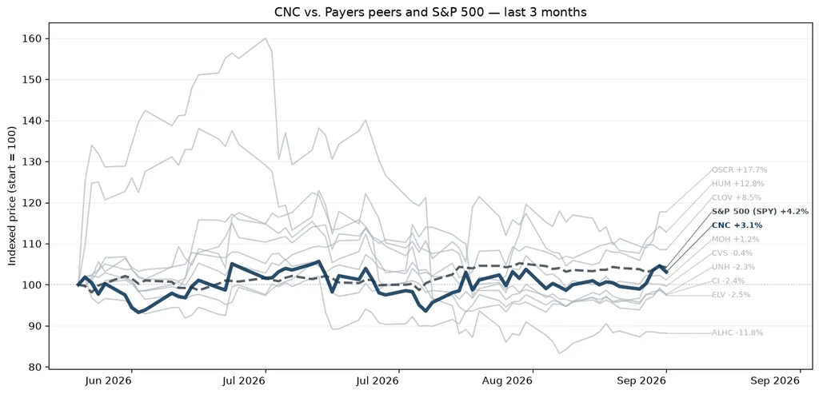

Centene is a managed care organization that focuses on government-sponsored healthcare plans, including Medicaid, Medicare, and the individual exchanges. Centene served 20 million medical members as of December 2025, mostly in Medicaid (about 64% of membership), the individual exchanges (about 28%), and Medicare (about 5%). The company also provides Medicare Part D pharmaceutical plans.

### Alignment Health (ALHC)

*Payers · $3.1B · 3m -11.9% · 12m -14.6% · 24m +42.5%*

[Google Finance](https://www.google.com/finance/quote/ALHC:NASDAQ?tab=earnings&hl=en)

Tech-enabled Medicare Advantage Company.

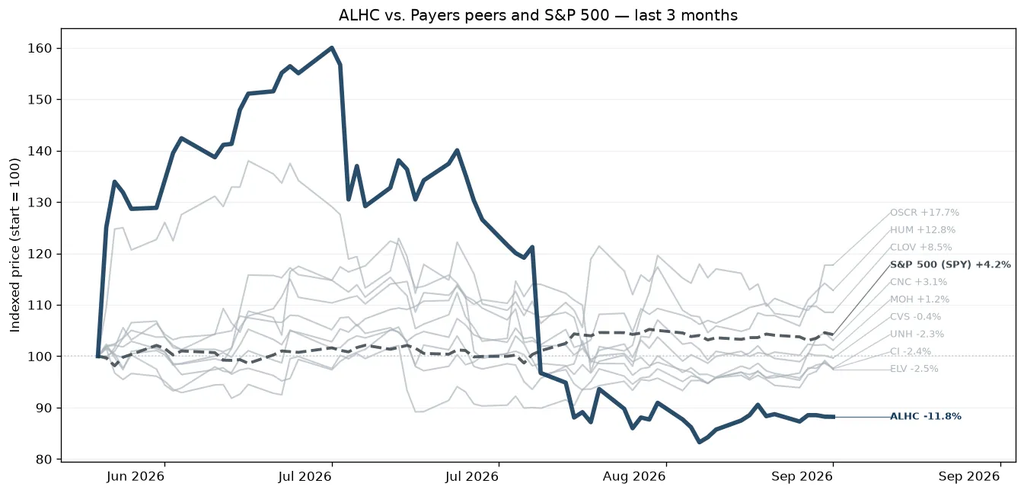

Alignment Healthcare Inc is a next-generation, consumer-centric platform that is revolutionizing the healthcare experience for seniors through Medicare Advantage plans. These plans are marketed and sold direct-to-consumer, allowing seniors to select the manner in which customers receive healthcare coverage and services on an annual basis. The company combines a technology platform and clinical model for more effective health outcomes.

### HCA Healthcare (HCA)

*Health System Providers · $87.2B · 3m +8.8% · 12m -3.7% · 24m +4.4%*

[Google Finance](https://www.google.com/finance/quote/HCA:NYSE?tab=earnings&hl=en)

Largest for-profit hospital and outpatient care operator in the United States.

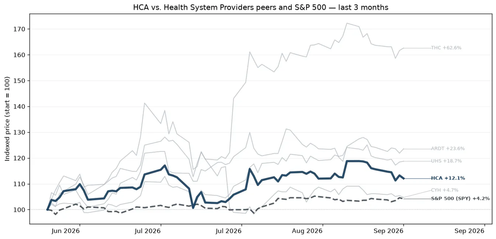

HCA Healthcare is a Nashville-based healthcare provider organization operating the largest collection of acute-care hospitals in the United States. As of December 2025, the firm owned and operated 190 hospitals and over 2,500 outpatient facillities across 19 states and a small foothold in the United Kingdom.

### Tenet Health (THC)

*Health System Providers · $20.5B · 3m +63.6% · 12m +35.1% · 24m +72.8%*

[Google Finance](https://www.google.com/finance/quote/THC:NYSE?tab=earnings&hl=en)

Diversified healthcare provider with hospitals and a leading ambulatory surgery center platform through USPI.

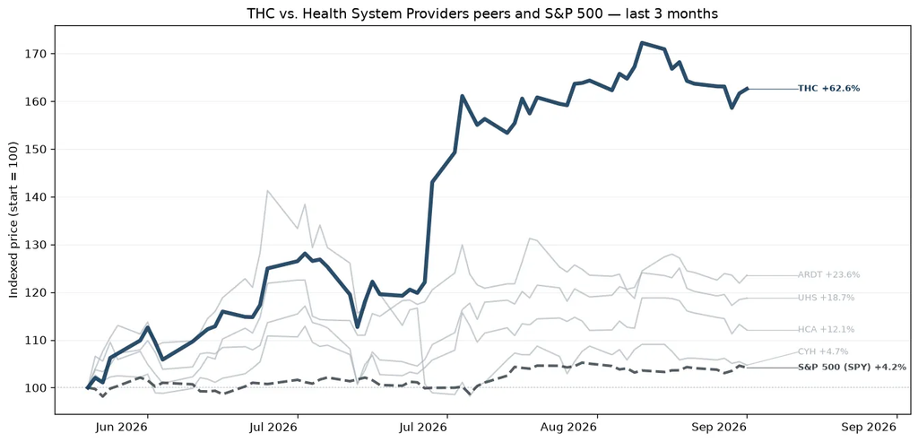

Tenet Healthcare is a Dallas-based healthcare services organization. It operates acute and specialty hospitals (50 as of December 2025) and hundreds of ambulatory surgery centers and other outpatient facilities across the US, primarily in the South. Through its Conifer segment, Tenet also provides revenue cycle management solutions.

### Universal Health Services (UHS)

*Health System Providers · $10.2B · 3m +16.9% · 12m -10.8% · 24m -26.0%*

[Google Finance](https://www.google.com/finance/quote/UHS:NYSE?tab=earnings&hl=en)

Hospital operator with significant acute care and behavioral health business.

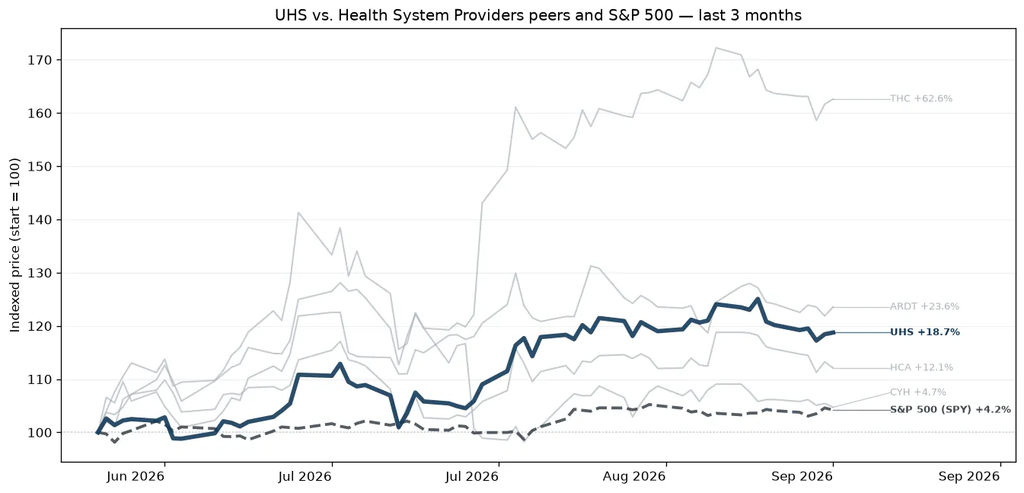

Universal Health Services Inc offers healthcare services through its behavioral health centers, acute care hospitals, and related outpatient facilities. As of late 2025, the company operated 346 inpatient behavioral health centers, 29 acute care hospitals, and many supportive outpatient facilities. Its operations are concentrated in the U.S, particularly in Nevada (21% of 2025 operating profits), Texas (19%), and California (13%), although it does have some exposure to the UK behavioral health market (6% of 2025 sales) too. While its acute care services account for over 55% of revenue, the behavioral health centers sport higher margins and account for over 55% of pretax profits.

### Community Health Systems (CYH)

*Health System Providers · $417.4M · 3m +5.5% · 12m -1.0% · 24m -49.3%*

[Google Finance](https://www.google.com/finance/quote/CYH:NYSE?tab=earnings&hl=en)

Operator of community hospitals primarily serving non-urban and regional markets.

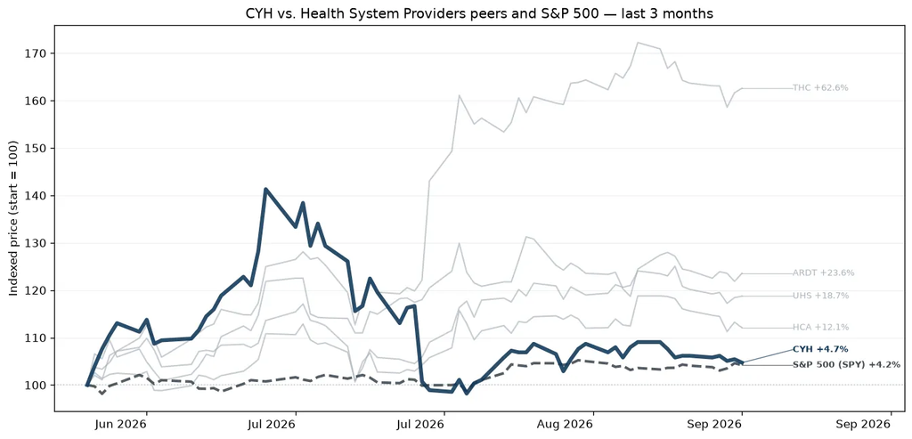

Community Health Systems Inc is a publicly owned hospital operator in the United States. The company also owns four home health agencies and provides management and consulting services to independent hospitals. The firm derives revenue through a broad range of general and specialized hospital healthcare services and outpatient services.

### Ardent Health Partners (ARDT)

*Health System Providers · $1.5B · 3m +25.7% · 12m -17.1% · 24m -43.1%*

[Google Finance](https://www.google.com/finance/quote/ARDT:NYSE?tab=earnings&hl=en)

Regional hospital operator focused on integrated health systems across mid-sized US markets.

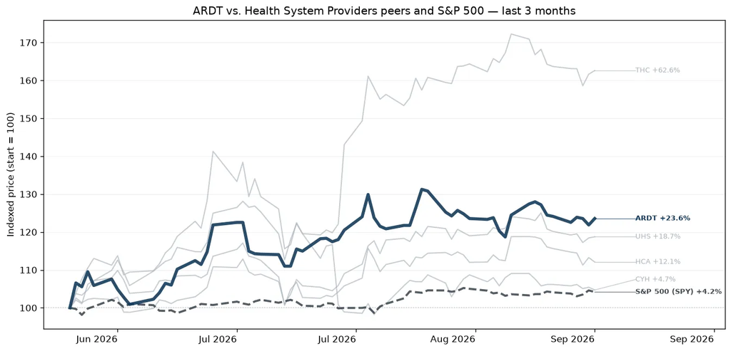

Ardent Health Inc is a provider of healthcare in growing mid-sized urban communities across the U.S and operating in eight growing mid-sized urban markets across six states Texas, Oklahoma, New Mexico, New Jersey, Idaho, and Kansas. The main focus on people and investments in services and technologies.

### The Ensign Group (ENSG)

[Google Finance](https://www.google.com/finance/quote/ENSG:NASDAQ?tab=earnings&hl=en)

Leading operator of skilled nursing facilities, rehabilitation centers, and senior-care services.

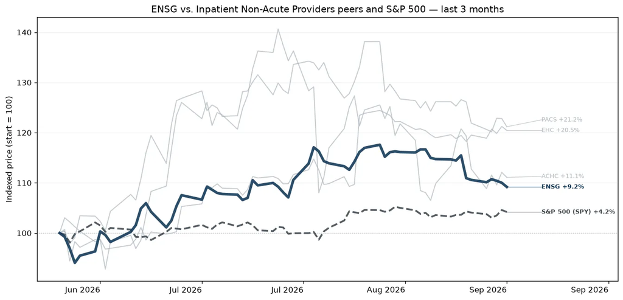

Ensign Group Inc provides post-acute healthcare services in the United States. Its regional subsidiaries oversee skilled nursing, assisted living, home health and hospice, mobile ancillary, and urgent care operations. Medicare and Medicaid programs contribute majority of revenue received for Ensign's services. The firm operates through two segments, Skilled services, and Standard Bearer. The skilled services segment includes the operation of skilled nursing facilities and rehabilitation therapy services. The Standard Bearer segment comprises of properties owned by the company through its captive REIT and leased to skilled nursing and assisted living operations. The majority of the revenue is generated from the skilled services segment.

### Acadia Healthcare (ACHC)

*Inpatient Non-Acute Providers · $2.8B · 3m +14.9% · 12m +18.6% · 24m -63.2%*

[Google Finance](https://www.google.com/finance/quote/ACHC:NASDAQ?tab=earnings&hl=en)

Largest provider of behavioral health and addiction treatment services.

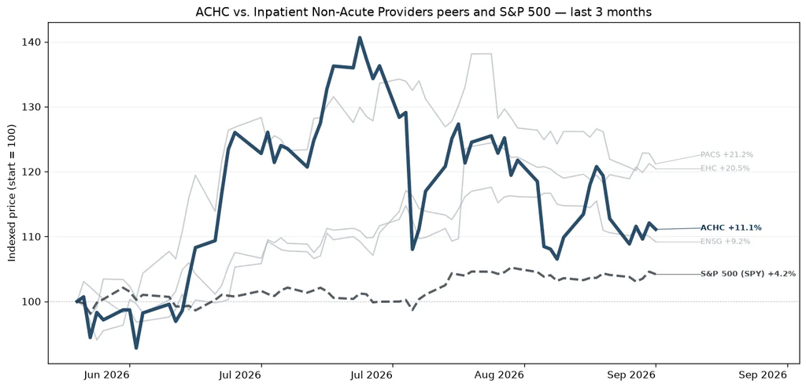

Acadia Healthcare Co Inc acquires and develops behavioral healthcare facilities. Its facilities and services are classified into the following categories: acute inpatient psychiatric facilities; specialty treatment facilities; CTCs; and residential treatment centers. In which Acute inpatient psychiatric facilities contribute the majority of revenue in the United States. The Company has one reportable segment, behavioral healthcare services. The behavioral healthcare services segment provides inpatient and outpatient behavioral healthcare services.

### Encompass Health (EHC)

*Inpatient Non-Acute Providers · $11.0B · 3m +17.1% · 12m -3.0% · 24m +32.9%*

[Google Finance](https://www.google.com/finance/quote/EHC:NYSE?tab=earnings&hl=en)

In-patient post-acute rehabilitation services.

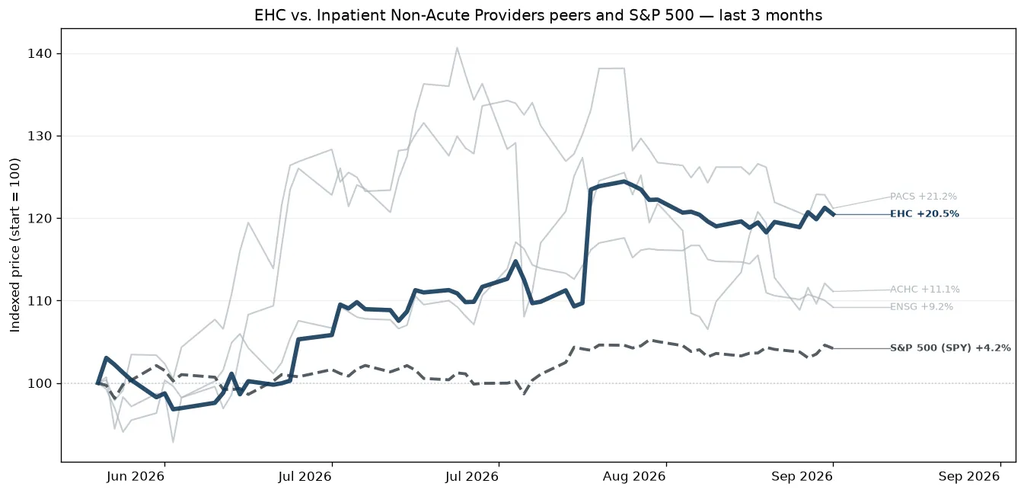

Encompass Health Corp provides post-acute healthcare services in the United States through a network of inpatient rehabilitation hospitals, which is the company's sole segment. Inpatient rehabilitation contributes the majority of the firm's revenue and provides specialized rehabilitative treatment through a network of inpatient hospitals. The company's inpatient rehabilitation hospitals provide a higher level of rehabilitative care to patients who are recovering from conditions such as stroke and other neurological disorders, cardiac and pulmonary conditions, brain and spinal cord injuries, complex orthopedic conditions, and amputations.

### PACS Group (PACS)

*Inpatient Non-Acute Providers · $7.3B · 3m +14.8% · 12m +280.5% · 24m +14.6%*

[Google Finance](https://www.google.com/finance/quote/PACS:NYSE?tab=earnings&hl=en)

Post-acute care and skilled nursing company.

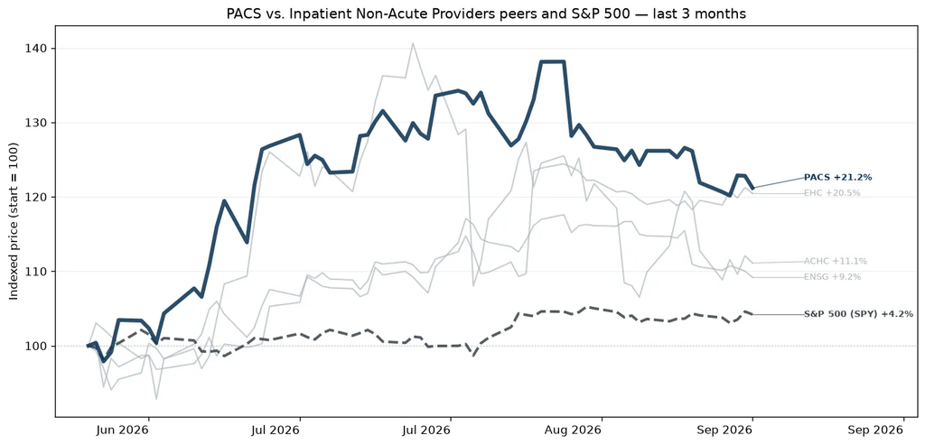

PACS Group Inc is a post-acute healthcare company mainly focused on delivering skilled nursing care through a portfolio of independently operated facilities. The post-acute care ecosystem serves individuals who need additional help recuperating from acute conditions, illnesses, or serious medical procedures after getting discharged from the hospital. It also provides senior care, assisted living, and independent living options in some of the communities. The company has one reportable segment.

### Healthpeak properties (DOC)

*Health Care Real Estate · $15.1B · 3m +4.3% · 12m +12.3% · 24m -6.1%*

[Google Finance](https://www.google.com/finance/quote/DOC:NYSE?tab=earnings&hl=en)

Healthcare industry real estate investment trust focused on outpatient medical offices, life science properties, an senior housing.

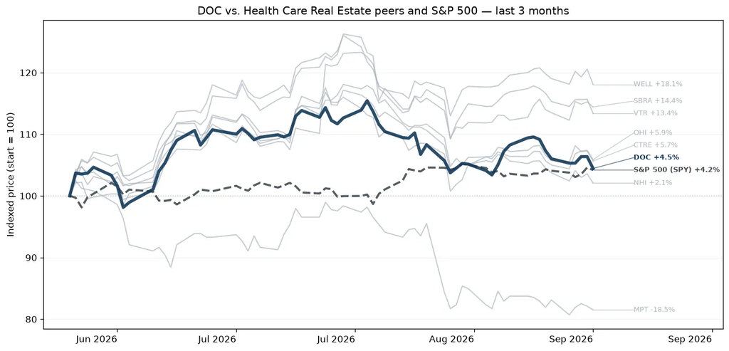

Healthpeak owns a diversified healthcare portfolio of approximately 700 in-place properties spread across mainly medical office and life science assets, plus a handful of senior housing, hospital, and skilled nursing/post-acute care assets, as well.

### Ventas, Inc (VTR)

*Health Care Real Estate · $48.0B · 3m +10.1% · 12m +32.9% · 24m +43.6%*

[Google Finance](https://www.google.com/finance/quote/VTR:NYSE?tab=earnings&hl=en)

Real estate investment trust focused on ownership and management of senior housing, research, medicine office buildings, and healthcare facilities.

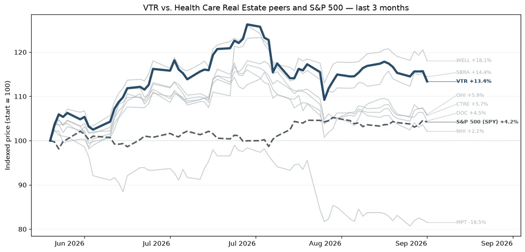

Ventas owns a diversified healthcare portfolio of almost 1,400 in-place properties spread across the senior housing, medical office, hospital, life science, and skilled nursing/post-acute care. The portfolio includes almost 100 properties in Canada and the United Kingdom as the company looks for additional investment opportunities in countries with mature healthcare systems that operate similarly to the United States. The firm also owns mortgages and other loans, contributing about 1% of net operating income.

### Medical Properties Trust (MPT)

*Health Care Real Estate · $2.8B · 3m -19.5% · 12m n/a · 24m n/a*

[Google Finance](https://www.google.com/finance/quote/MPT:NYSE?tab=earnings&hl=en)

Real estate investment trust for healthcare facilities in the US and Europe.

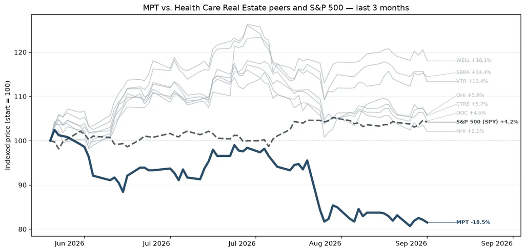

Medical Properties Trust Inc acquires and develops net-leased healthcare facilities. Its investments in healthcare real estate, other loans, and any investments in tenants are considered a single reportable segment. Its business strategy is to acquire and develop healthcare facilities and lease the facilities to healthcare operating companies under long-term net leases, which require the tenant to bear of the costs associated with the property. The group's geographic areas are the United States, the United Kingdom, and All other countries.

### National Health Investors (NHI)

*Health Care Real Estate · $3.7B · 3m +0.6% · 12m -9.6% · 24m -13.9%*

[Google Finance](https://www.google.com/finance/quote/NHI:NYSE?tab=earnings&hl=en)

Healthcare REIT focused on senior housing, skilled nursing, and long-term care properties.

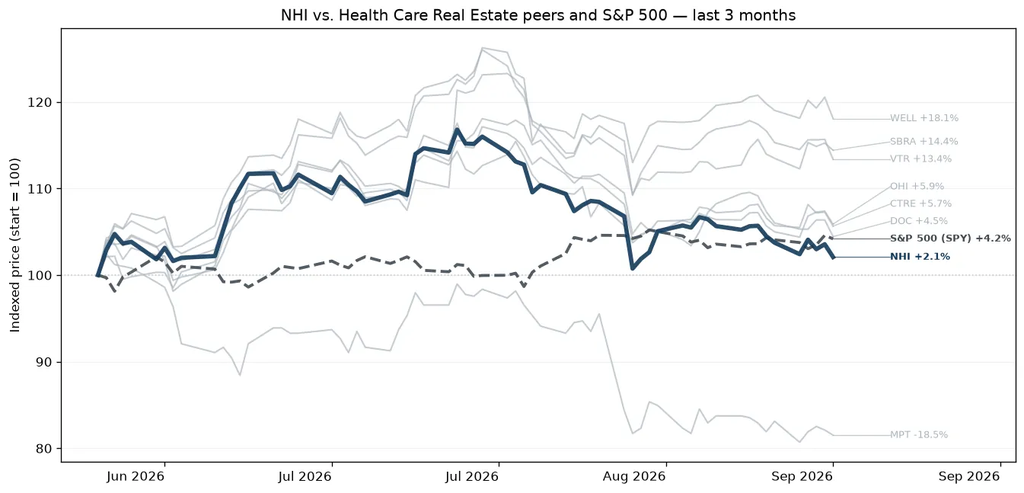

National Health Investors Inc is a self-managed REIT that owns, leases, operates, and finances the development of senior housing communities and medical facilities. It operates through two segments: Real Estate Investments and Senior Housing Operating Portfolio (SHOP). The Real Estate Investments segment, which generates the majority of revenue, includes real estate leases, mortgages, and other notes receivable related to independent living facilities, assisted living facilities, entrance fee communities, senior living campuses, skilled nursing facilities, and a hospital. The SHOP segment consists of ventures that own and operate independent living facilities. The company's revenues are derived from rental income, interest and other income, and resident fees and services.

### Omega Healthcare Investors (OHI)

*Health Care Real Estate · $15.1B · 3m +4.3% · 12m +7.5% · 24m +17.0%*

[Google Finance](https://www.google.com/finance/quote/OHI:NYSE?tab=earnings&hl=en)

Healthcare REIT healthcare REIT focused on skilled nursing and assisted living facilities.

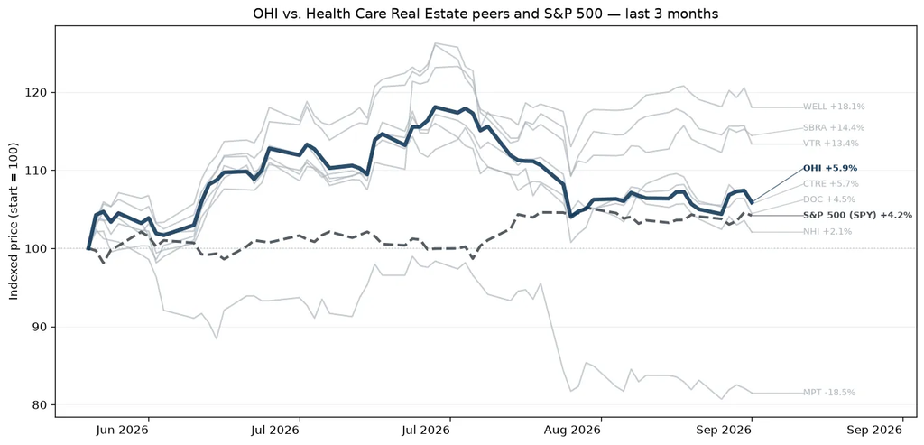

Omega Healthcare Investors Inc is a real estate investment trust that invests in healthcare-related real estate properties located in the United States (U.S.), the United Kingdom (U.K.), and Canada. The company's objective is to provide attractive returns to investors while serving as the preferred capital partner to its third-party healthcare operating companies and affiliates, as well as other third-party healthcare operators, allowing them to focus on delivering a high level of care to their resident patients. Omega's investment portfolio mainly consists of skilled nursing facilities, assisted living facilities (ALFs), including care homes in the U.K., independent living facilities, rehabilitation and acute care facilities, and continuing care retirement communities.

### Welltower (WELL)

*Health Care Real Estate · $166.9B · 3m +14.1% · 12m +40.7% · 24m +89.5%*

[Google Finance](https://www.google.com/finance/quote/WELL:NYSE?tab=earnings&hl=en)

Largest healthcare REIT, focused on senior housing, outpatient medical, and wellness-oriented healthcare properties.

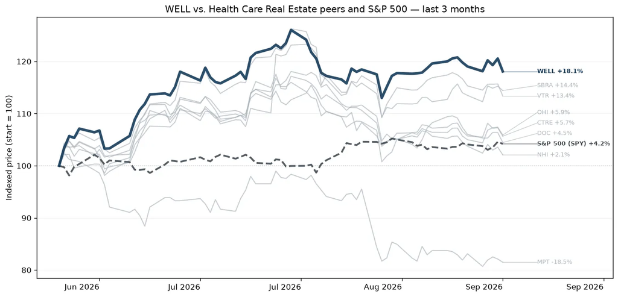

Welltower owns a diversified healthcare portfolio of 2,800 in-place properties spread across the senior housing, medical office, and skilled nursing/postacute care sectors. The portfolio includes over 900 properties in Canada and the United Kingdom as the company looks for additional investment opportunities in countries with mature healthcare systems that operate similarly to that of the United States.

### CareTrust REIT (CTRE)

*Health Care Real Estate · $9.6B · 3m +2.7% · 12m +14.9% · 24m +31.0%*

[Google Finance](https://www.google.com/finance/quote/CTRE:NYSE?tab=earnings&hl=en)

Healthcare REIT focused on skilled nursing, senior housing, and other post-acute care facilities.

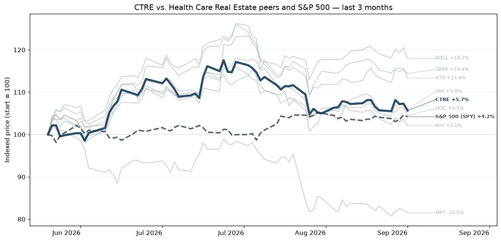

CareTrust REIT Inc is a self-administered, publicly traded REIT engaged in the ownership, acquisition, financing, development, and leasing of skilled nursing, seniors housing, and other healthcare-related properties. The company has one reportable segment consisting of investments in healthcare-related real estate assets. It generates revenues by leasing healthcare-related properties to healthcare operators under triple-net lease arrangements, in which the tenant is solely responsible for property-related costs. The company operates in Domestic and Foreign markets, with the majority of revenue coming from Domestic operations.

### Sabra Health Care REIT (SBRA)

*Health Care Real Estate · $5.3B · 3m +12.6% · 12m +9.2% · 24m +20.5%*

[Google Finance](https://www.google.com/finance/quote/SBRA:NASDAQ?tab=earnings&hl=en)

healthcare REIT focused on skilled nursing, senior housing, and behavioral health properties.

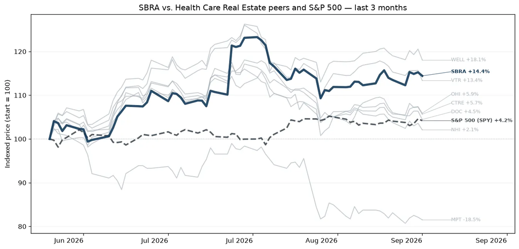

Sabra Health Care REIT Inc is a healthcare facility real estate investment trust. The company operates one segment that owns and invests in healthcare real estate. All of the company's revenue is generated in the United States. Sabra's operations consist of nursing facilities, assisted living centers, and mental health facilities.